# Extrapolating Neural Network Accuracy Across Data Sources

- Introduction
  - Research Question
  - Objectives and Goals
  - Imports and Setup
- Data Cleaning
  - Load and Preview the Data
  - Text Cleanliness
    - Extra Characters
    - Remove Stopwords
    - Lemmatization
    - Cleaned Text
  - Tokenization and Padding
- Training, Validation, and Testing Data
- The NLP Neural Network
  - Initial Network
    - Build the Network
    - Fit the Network
    - Network Accuracy
  - Final Network
- Accuracy
  - Testing Data
  - Secondary Data
- Recommendations

## Introduction

### Research Question

With what level of accuracy does a natural language processing (NLP) neural network trained on the Sentiment Labelled Data Set (Kotzias, 2015) to predict sentiment from customer reviews, extrapolate to reviews from other data sources?

### Objectives and Goals

- **Goal 1**: Develop an NLP neural network capable of accurately classifying positive and negative sentiment from the Sentiment Labelled Sentences Data Set.
  - **Objective 1**: Clean the text data of extra characters.
  - **Objective 2**: Prepare the data for analysis by removing stopwords, lemmatizing, tokenizing and padding the text.
  - **Objective 3**: Build and fit the NLP neural network.
- **Goal 2**: Test the accuracy of the neural network from Goal 1 against a sentiment labelled data set from a different source.
  - **Objective 1**: Identify and obtain review data from a second source.
  - **Objective 2**: Clean and prepare the data as was done for Goal 1.
  - **Objectibe 3**: Make predictions on the data and assess the accuracy.

### Imports and Setup

```python
import tensorflow as tf
import os
import string
import warnings
import numpy as np
import pandas as pd
import matplotlib.pyplot as plt
from datetime import datetime
from pprint import pprint
from nltk.corpus import stopwords
from nltk.stem import WordNetLemmatizer
from wordcloud import WordCloud
from tensorflow.keras.preprocessing.text import Tokenizer
from tensorflow.keras.preprocessing.sequence import pad_sequences
from tensorflow.keras.models import Sequential, load_model
from tensorflow.keras.layers import Embedding, Dense, Dropout, LSTM
from tensorflow.keras.callbacks import EarlyStopping
from sklearn.model_selection import train_test_split
from sklearn.metrics import accuracy_score, \
    confusion_matrix, ConfusionMatrixDisplay

# Constants
OUT = 'output2'
PATHS = ['./sentiment_labelled_sentences/amazon_cells_labelled.txt',
         './sentiment_labelled_sentences/imdb_labelled.txt',
         './sentiment_labelled_sentences/yelp_labelled.txt']

warnings.simplefilter('ignore')

print(f'Tensorflow version check: {tf.__version__}')
```

```
Tensorflow version check: 2.11.0
```

## Data Cleaning

### Load and Preview the Data

```python
data = []
for path in PATHS:
    with open(path) as file:
        data.extend(file.readlines())

text = [row.split('\t')[0].lower() for row in data]
sentiment = [int(row.split('\t')[1][0]) for row in data]
df = pd.DataFrame().from_dict({'text': text, 'sentiment': sentiment})
df.head()
```

|  | text | sentiment |
| --- | --- | --- |
| 0 | so there is no way for me to plug it in here i... | 0 |
| 1 | good case, excellent value. | 1 |
| 2 | great for the jawbone. | 1 |
| 3 | tied to charger for conversations lasting more... | 0 |
| 4 | the mic is great. | 1 |

The data consists of 3,000 text reviews and sentiment. Values of 1 represent positive sentiment and values of 0 represent negative sentiment. There are an equal number of positive and negative reviews in the data set, 1,500 positive and 1,500 negative.

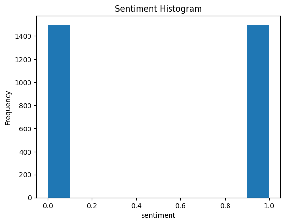

```
Sentiment Value Counts:
```

```
0    1500
1    1500
Name: sentiment, dtype: int64
```

```python
df.sentiment.plot(kind='hist', title='Sentiment Histogram')
plt.xlabel('sentiment')
plt.savefig(os.path.join(OUT, 'sentiment_hist.png'))
plt.show()

print('Sentiment Value Counts:')
df.sentiment.value_counts()
```

### Text Cleanliness

#### Extra Characters

Any characters other than ASCII characters, consisting of the upper- and lower-case English alphabet, and spaces were identified and removed.

```python
characters = string.ascii_letters + ' '
extra_chars = sorted(set([char for row in df.text.values
                            for char in row
                                if char not in characters]))
print(extra_chars)

df.text = df.text.apply(lambda row: ''.join([char for char in row
                                                if char in characters]))
df.head()
```

```
['!', '"', '#', '$', '%', '&', "'", '(', ')', '*', '+', ',', '-', '.', '/', '0', '1', '2', '3', '4', '5', '6', '7', '8', '9', ':', ';', '?', '[', ']', '¥', '©', 'ª', 'â', 'ã', '–', '—', '…']
```

|  | text | sentiment |
| --- | --- | --- |
| 0 | so there is no way for me to plug it in here i... | 0 |
| 1 | good case excellent value | 1 |
| 2 | great for the jawbone | 1 |
| 3 | tied to charger for conversations lasting more... | 0 |
| 4 | the mic is great | 1 |

#### Remove Stopwords

Words like "is" and "the" were removed because they appear so frequently in both positive and negative reviews.

```python
def remove_stopwords(text: str) -> str:
    stopword_set = set(stopwords.words('english'))
    temp = text.split()
    for stopword in stopword_set:
        if stopword in temp:
            temp.remove(stopword)
    return ' '.join(temp)

df.text = df.text.apply(remove_stopwords)
df.head()
```

|  | text | sentiment |
| --- | --- | --- |
| 0 | way plug in us unless go converter | 0 |
| 1 | good case excellent value | 1 |
| 2 | great jawbone | 1 |
| 3 | tied charger conversations lasting minutesmajo... | 0 |
| 4 | mic great | 1 |

#### Lemmatization

Each remaining word was stripped down to its base word using lemmatization.

```python
def lemmatize_text(text: str) -> str:
    lemmatizer = WordNetLemmatizer()
    for pos in ['n', 'v', 'a', 'r', 's']:
        text = ' '.join([lemmatizer.lemmatize(word, pos)
                            for word in text.split()])
    return text

df.text = df.text.apply(lemmatize_text)
df.head()
```

|  | text | sentiment |
| --- | --- | --- |
| 0 | way plug in u unless go converter | 0 |
| 1 | good case excellent value | 1 |
| 2 | great jawbone | 1 |
| 3 | tie charger conversation last minutesmajor pro... | 0 |
| 4 | mic great | 1 |

#### Cleaned Text

With the data cleaned, a wordcloud was used to visualize the relative frequency of each word.

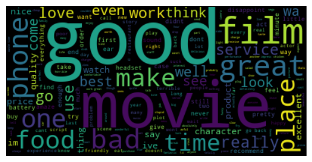

```python
textt = ' '.join(df.text)
wordcloud = WordCloud().generate(textt)
plt.imshow(wordcloud, interpolation='bilinear')
plt.axis('off')
plt.savefig(os.path.join(OUT, 'word_cloud.png'))
plt.show()
```

### Tokenization and Padding

To determine the best length to use for padding, the word count distribution was reviewed.

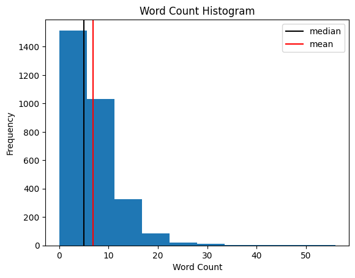

```python
word_count = [len(x.split()) for x in df.text]

plt.hist(word_count)
plt.axvline(np.median(word_count), color='black', label='median')
plt.axvline(np.mean(word_count), color='red', label='mean')
plt.title('Word Count Histogram')
plt.xlabel('Word Count')
plt.ylabel('Frequency')
plt.legend()
plt.savefig(os.path.join(OUT, 'word_count_hist.png'))
plt.show()
```

There is a positive skew to the data, indicating that there are outliers. To determine the cutoff, the mean plus 3 standard deviations was calculated and rounded up to the nearest integer.

A tokenizer, mapped to the unique vocabulary set, was used to create the sequences, which were then trimmed or padded to the maximum length.

```python
word_count_std = np.std(word_count)
max_len = int(np.ceil(np.mean(word_count) + (3 * word_count_std)))
vocab_size = len(set(textt.split()))
tokenizer = Tokenizer(num_words=vocab_size)
tokenizer.fit_on_texts(df.text.values)
encoded_docs = tokenizer.texts_to_sequences(df.text.values)
padded_sequence = pad_sequences(encoded_docs, maxlen=max_len, padding='post')
print(f'vocabulary size: {vocab_size}\n'
      f'max length: {max_len} words\n'
      f'original text: {df.text[0]}\n'
      f'encoded text: {encoded_docs[0]}\n'
      f'padded sequence:\n{padded_sequence[0]}')
```

```
vocabulary size: 4288
max length: 22 words
original text: way plug in u unless go converter
encoded text: [60, 225, 109, 125, 557, 17, 1851]
padded sequence:
[  60  225  109  125  557   17 1851    0    0    0    0    0    0    0
    0    0    0    0    0    0    0    0]
```

## Training, Validation, and Testing Data

The data was first split into the training data and a 40% chunk. The extra chunk was then split in half to produce the validation and testing data. The final allocations were:

- 60% training data
- 20% validation data
- 20% testing data

All six of the resulting data sets were extracted to comma delimited files.

```python
X_train, X_temp, y_train, y_temp = \
    train_test_split(padded_sequence, df.sentiment, test_size=0.4,
                     stratify=df.sentiment, random_state=42)
X_val, X_test, y_val, y_test = \
    train_test_split(X_temp, y_temp, test_size=0.5,
                     stratify=y_temp, random_state=42)

y_train = np.array(y_train)
y_val = np.array(y_val)
y_test = np.array(y_test)

pd.DataFrame(X_train).to_csv(os.path.join(OUT, 'X_train.csv'), index=False)
pd.DataFrame(y_train).to_csv(os.path.join(OUT, 'y_train.csv'), index=False)
pd.DataFrame(X_val).to_csv(os.path.join(OUT, 'X_val.csv'), index=False)
pd.DataFrame(y_val).to_csv(os.path.join(OUT, 'y_val.csv'), index=False)
pd.DataFrame(X_test).to_csv(os.path.join(OUT, 'X_test.csv'), index=False)
pd.DataFrame(y_test).to_csv(os.path.join(OUT, 'y_test.csv'), index=False)
```

## The NLP Neural Network

### Initial Network

#### Build the Network

```python
embedding_vector_length = 600
model1 = Sequential()
model1.add(Embedding(vocab_size, embedding_vector_length, input_length=max_len))
model1.add(LSTM(100))
model1.add(Dense(1, activation='sigmoid'))
model1.compile(loss='binary_crossentropy', optimizer='adam', metrics=['accuracy'])
model1.summary()
```

```
Model: "sequential"
_________________________________________________________________
 Layer (type)                Output Shape              Param #
=================================================================
 embedding (Embedding)       (None, 22, 600)           2572800

 lstm (LSTM)                 (None, 100)               280400

 dense (Dense)               (None, 1)                 101

=================================================================
Total params: 2,853,301
Trainable params: 2,853,301
Non-trainable params: 0
_________________________________________________________________
```

#### Fit the Network

```python
history1 = model1.fit(X_train, y_train, epochs=10, batch_size=32,
                      validation_data=[X_val, y_val])
```

#### Network Accuracy

The accuracy score was used to assess network accuracy. This and the loss metric, binary cross-entropy, was plotted for each epoch of the fitting process.

```python
def plot_learning_curve(hx_obj, epochs: int) -> None:
    epoch_range = range(1, epochs + 1)
    _, (ax1, ax2) = plt.subplots(2, figsize=(6, 8), sharex=True)
    ax1.plot(epoch_range, hx_obj.history['accuracy'], label='Train')
    ax1.plot(epoch_range, hx_obj.history['val_accuracy'], label='Val')
    ax1.set_title('Model Accuracy')
    ax1.set_ylabel('Accuracy')
    ax1.legend()
    ax2.plot(epoch_range, hx_obj.history['loss'], label='Train', scaley='log')
    ax2.plot(epoch_range, hx_obj.history['val_loss'], label='Val', scaley='log')
    ax2.set_yscale('log')
    ax2.set_title('Model Loss')
    ax2.set_ylabel('Loss (log scale)')
    ax2.set_xlabel('Epoch')
    ax2.legend()
    plt.tight_layout()
    plt.savefig(os.path.join(OUT, f"accuracy_{datetime.now().strftime('%Y%m%d%H%M%S')}.png"))
    plt.show()
```

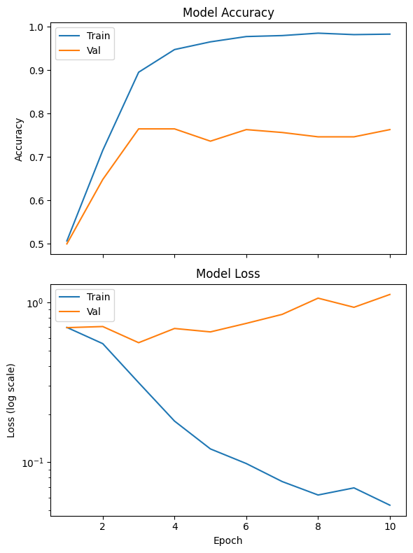

```python
plot_learning_curve(history1, len(history1.history['accuracy']))
```

It is quite apparent that the network has overfit to the training data considering the training loss is only 0.05 but the validation loss is 1.12.

### Final Network

To improve on the initial model, a Dense layer was added between the LSTM and output Dense layers to help classify the sentiment extracted by the LSTM layer. Adding this layer will make the network even more proned to overfitting than before, so an early stopping monitor was added to stop the model if it goes 2 epochs without improving. The summary, fit, and accuracy plots can be seen below.

```
Model: "sequential_5"
_________________________________________________________________
 Layer (type)                Output Shape              Param #
=================================================================
 embedding_5 (Embedding)     (None, 22, 600)           2572800

 lstm_5 (LSTM)               (None, 100)               280400

 dense_9 (Dense)             (None, 50)                5050

 dense_10 (Dense)            (None, 1)                 51

=================================================================
Total params: 2,858,301
Trainable params: 2,858,301
Non-trainable params: 0
_________________________________________________________________
None
```

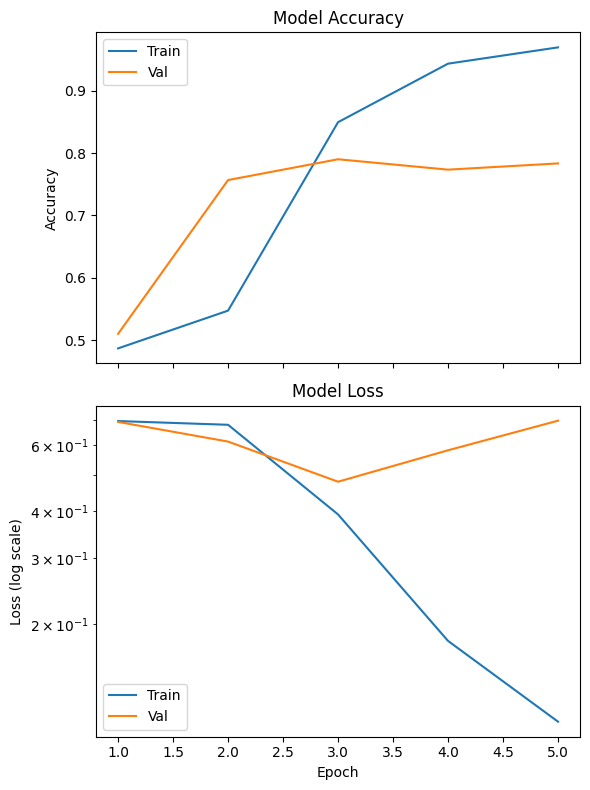

```python
early_stopping_monitor = EarlyStopping(patience=2)
model2 = Sequential()
model2.add(Embedding(vocab_size,
                     embedding_vector_length,
                     input_length=max_len))
model2.add(LSTM(100))
model2.add(Dense(50, activation='relu'))
model2.add(Dense(1, activation='sigmoid'))
model2.compile(optimizer='adam',
               loss='binary_crossentropy',
               metrics=['accuracy'])
print(model2.summary())
history2 = model2.fit(X_train, y_train, epochs=20, batch_size=32,
                      validation_data=[X_val, y_val],
                      callbacks=[early_stopping_monitor])
plot_learning_curve(history2, len(history2.history['accuracy']))
```

After testing a few different hyperparameter combinations, the final validation loss improved from the initial model, dropping to about 0.7. With the fitting complete, the model was saved for future use.

```python
model2.save(os.path.join(OUT, 'fitted_model.h5'))
```

## Accuracy

### Testing Data

```
Accuracy: 0.78
```

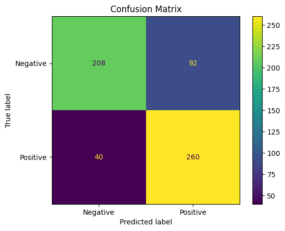

```python
model = load_model(os.path.join(OUT, 'fitted_model.h5'))
predictions = model.predict(X_test)
predictions = np.round(predictions)
accuracy = accuracy_score(y_test, predictions)
print('Accuracy:', accuracy)
cm = confusion_matrix(y_test, predictions)
disp = ConfusionMatrixDisplay(confusion_matrix=cm, display_labels=['Negative', 'Positive'])
disp.plot()
plt.title('Confusion Matrix')
plt.savefig(os.path.join(OUT, 'confusion_matrix.png'))
plt.show()
```

### Secondary Data

The secondary data set that was selected was the Google Local Data (2021) from [(2021, Zhang, T.; Li, J.;)](https://jiachengli1995.github.io/google/index.html). There are 666,324,103 reviews available in total. Only a subset of 20,000 records from the state of Michigan containing ~13 million records were downloaded.

```python
test_df =  pd.read_json('review-Michigan_10.json', orient='records', nrows=20000, lines=True)
test_df = test_df[['text', 'rating']]
test_df
```

|  | text | rating |
| --- | --- | --- |
| 0 | I have been with Sara as my Agent for many yea... | 5 |
| 1 | I went to this allstate because I needed a new... | 1 |
| 2 | Everyone at this office is great! They make m... | 5 |
| 3 | Great service | 5 |
| 4 | Friendly | 5 |
| ... | ... | ... |
| 19995 | None | 5 |
| 19996 | Thank you for your kind compassion during\nThi... | 5 |
| 19997 | I recently met with Mandy from Gorsline-Runcim... | 5 |
| 19998 | Very caring. Did a perfect job with my mothers... | 5 |
| 19999 | All the staff were very helpful and understand... | 5 |

20000 rows × 2 columns

Null values were identified and dropped.

```python
print(test_df.isna().sum())
test_df = test_df[~test_df.text.isna()]
test_df
```

```
text      7466
rating       0
dtype: int64
```

|  | text | rating |
| --- | --- | --- |
| 0 | I have been with Sara as my Agent for many yea... | 5 |
| 1 | I went to this allstate because I needed a new... | 1 |
| 2 | Everyone at this office is great! They make m... | 5 |
| 3 | Great service | 5 |
| 4 | Friendly | 5 |
| ... | ... | ... |
| 19992 | Awesome prices and products | 5 |
| 19996 | Thank you for your kind compassion during\nThi... | 5 |
| 19997 | I recently met with Mandy from Gorsline-Runcim... | 5 |
| 19998 | Very caring. Did a perfect job with my mothers... | 5 |
| 19999 | All the staff were very helpful and understand... | 5 |

12534 rows × 2 columns

The ratings were plotted to determine what transformations were required.

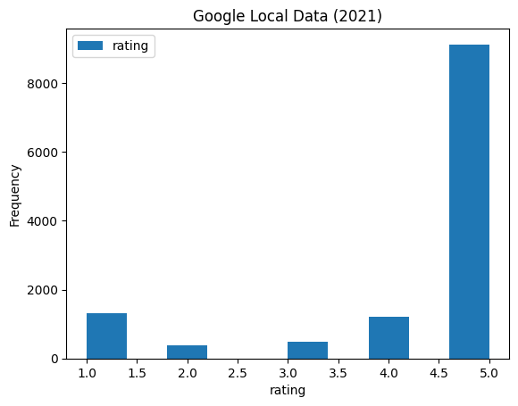

```python
test_df.plot(kind='hist')
plt.title('Google Local Data (2021)')
plt.xlabel('rating')
plt.show()
```

Values of 1 and 2 were mapped to 0 or negative sentiment. Values of 4 and 5 were mapped to 1 or positive sentiment. Values of 3 were considered neutral and were dropped.

```python
test_df = test_df.loc[~test_df.rating.eq(3)]
test_df['sentiment'] = test_df.rating.replace({1: 0, 2: 0, 4: 1, 5: 1}).apply(int)
test_df.sentiment.value_counts()
```

```
1    10339
0     1713
Name: sentiment, dtype: int64
```

The vast majority of the reviews were positive.

To aid with the remaining tasks required to produce predictions, the following function was written.

```python
def predict_sentiment(text: pd.Series):
    # lower-case and remove special characters
    characters = string.ascii_letters + ' '
    text = text.apply(lambda x: ''.join([char for char in x.lower() if char in characters]))
    # remove stopwords
    text = text.apply(remove_stopwords)
    # Lemmetization
    text = text.apply(lemmatize_text)
    # encode text
    encoded_text = tokenizer.texts_to_sequences(text.values)
    # pad encoded text
    padded_text = pad_sequences(encoded_text, maxlen=22, padding='post')
    # make prediction
    output = model.predict(padded_text)
    # round output
    prediction = np.round(output)
    # return output as int
    return [int(x) for x in prediction]
```

The predictions were made and added as another column.

```python
test_df['prediction'] = predict_sentiment(test_df.text)
test_df
```

|  | text | rating | sentiment | prediction |
| --- | --- | --- | --- | --- |
| 0 | I have been with Sara as my Agent for many yea... | 5 | 1 | 1 |
| 1 | I went to this allstate because I needed a new... | 1 | 0 | 0 |
| 2 | Everyone at this office is great! They make m... | 5 | 1 | 0 |
| 3 | Great service | 5 | 1 | 1 |
| 4 | Friendly | 5 | 1 | 1 |
| ... | ... | ... | ... | ... |
| 19992 | Awesome prices and products | 5 | 1 | 1 |
| 19996 | Thank you for your kind compassion during\nThi... | 5 | 1 | 1 |
| 19997 | I recently met with Mandy from Gorsline-Runcim... | 5 | 1 | 0 |
| 19998 | Very caring. Did a perfect job with my mothers... | 5 | 1 | 1 |
| 19999 | All the staff were very helpful and understand... | 5 | 1 | 1 |

12052 rows × 4 columns

Finally, the accuracy score was calculated.

```
Accuracy Score: 0.8255061400597411
```

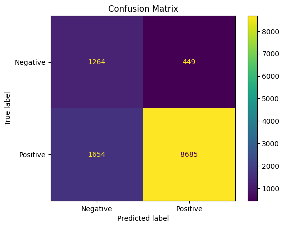

```python
test_df.dropna(inplace=True)
sentiment = test_df.loc[~test_df.rating.eq(3), 'sentiment']
prediction = test_df.loc[~test_df.rating.eq(3), 'prediction']

accuracy = accuracy_score(sentiment, prediction)
print('Accuracy Score:', accuracy)

cm = confusion_matrix(sentiment, prediction)
disp = ConfusionMatrixDisplay(confusion_matrix=cm, display_labels=['Negative', 'Positive'])
disp.plot()
plt.title('Confusion Matrix')
plt.savefig(os.path.join(OUT, 'google_confusion_matrix.png'))
plt.show()
```

Surprisingly, the accuracy score for the predictions on the secondary data is higher than the validation or testing data sets.

## Recommendations

Based on the accuracy scores observed in the testing and secondary data, this model does contain some value for training an NLP neural network. While I would not recommend placing a model achieving an 80% accuracy score into a high-stakes production environment, this data could be appended to additional data to make a very robust network.